# Week 4 HW

### 7.5.1.1

#### 1. Use what you’ve learned to improve the visualisation of the departure times of cancelled vs. non-cancelled flights.

```r
#so, comparing schedule departure times b/w cancelled/not cancelled, since cancelled flights
#never departed
#need to gather sched_dep_time for all rows where dep_time = NA, and compare to sched_dep_time for non-cancelled flights
#use boxplot, coord_flip()

glimpse(flights)
```

```
## Observations: 336,776
## Variables: 19
## $ year           <int> 2013, 2013, 2013, 2013, 2013, 2013, 2013, 2013, 2013...
## $ month          <int> 1, 1, 1, 1, 1, 1, 1, 1, 1, 1, 1, 1, 1, 1, 1, 1, 1, 1...
## $ day            <int> 1, 1, 1, 1, 1, 1, 1, 1, 1, 1, 1, 1, 1, 1, 1, 1, 1, 1...
## $ dep_time       <int> 517, 533, 542, 544, 554, 554, 555, 557, 557, 558, 55...
## $ sched_dep_time <int> 515, 529, 540, 545, 600, 558, 600, 600, 600, 600, 60...
## $ dep_delay      <dbl> 2, 4, 2, -1, -6, -4, -5, -3, -3, -2, -2, -2, -2, -2,...
## $ arr_time       <int> 830, 850, 923, 1004, 812, 740, 913, 709, 838, 753, 8...
## $ sched_arr_time <int> 819, 830, 850, 1022, 837, 728, 854, 723, 846, 745, 8...
## $ arr_delay      <dbl> 11, 20, 33, -18, -25, 12, 19, -14, -8, 8, -2, -3, 7,...
## $ carrier        <chr> "UA", "UA", "AA", "B6", "DL", "UA", "B6", "EV", "B6"...
## $ flight         <int> 1545, 1714, 1141, 725, 461, 1696, 507, 5708, 79, 301...
## $ tailnum        <chr> "N14228", "N24211", "N619AA", "N804JB", "N668DN", "N...
## $ dest           <chr> "IAH", "IAH", "MIA", "BQN", "ATL", "ORD", "FLL", "IA...
## $ air_time       <dbl> 227, 227, 160, 183, 116, 150, 158, 53, 140, 138, 149...
## $ distance       <dbl> 1400, 1416, 1089, 1576, 762, 719, 1065, 229, 944, 73...
## $ hour           <dbl> 5, 5, 5, 5, 6, 5, 6, 6, 6, 6, 6, 6, 6, 6, 6, 5, 6, 6...
## $ minute         <dbl> 15, 29, 40, 45, 0, 58, 0, 0, 0, 0, 0, 0, 0, 0, 0, 59...
## $ time_hour      <dttm> 2013-01-01 05:00:00, 2013-01-01 05:00:00, 2013-01-0...
## $ na_origin      <chr> NA, "LGA", "JFK", "JFK", "LGA", NA, NA, "LGA", "JFK"...
```

```r
summary(flights)
```

```
##       year          month             day           dep_time    sched_dep_time
##  Min.   :2013   Min.   : 1.000   Min.   : 1.00   Min.   :   1   Min.   : 106
##  1st Qu.:2013   1st Qu.: 4.000   1st Qu.: 8.00   1st Qu.: 907   1st Qu.: 906
##  Median :2013   Median : 7.000   Median :16.00   Median :1401   Median :1359
##  Mean   :2013   Mean   : 6.549   Mean   :15.71   Mean   :1349   Mean   :1344
##  3rd Qu.:2013   3rd Qu.:10.000   3rd Qu.:23.00   3rd Qu.:1744   3rd Qu.:1729
##  Max.   :2013   Max.   :12.000   Max.   :31.00   Max.   :2400   Max.   :2359
##                                                  NA's   :8255
##    dep_delay          arr_time    sched_arr_time   arr_delay
##  Min.   : -43.00   Min.   :   1   Min.   :   1   Min.   : -86.000
##  1st Qu.:  -5.00   1st Qu.:1104   1st Qu.:1124   1st Qu.: -17.000
##  Median :  -2.00   Median :1535   Median :1556   Median :  -5.000
##  Mean   :  12.64   Mean   :1502   Mean   :1536   Mean   :   6.895
##  3rd Qu.:  11.00   3rd Qu.:1940   3rd Qu.:1945   3rd Qu.:  14.000
##  Max.   :1301.00   Max.   :2400   Max.   :2359   Max.   :1272.000
##  NA's   :8255      NA's   :8713                  NA's   :9430
##    carrier              flight       tailnum              dest
##  Length:336776      Min.   :   1   Length:336776      Length:336776
##  Class :character   1st Qu.: 553   Class :character   Class :character
##  Mode  :character   Median :1496   Mode  :character   Mode  :character
##                     Mean   :1972
##                     3rd Qu.:3465
##                     Max.   :8500
##
##     air_time        distance         hour           minute
##  Min.   : 20.0   Min.   :  17   Min.   : 1.00   Min.   : 0.00
##  1st Qu.: 82.0   1st Qu.: 502   1st Qu.: 9.00   1st Qu.: 8.00
##  Median :129.0   Median : 872   Median :13.00   Median :29.00
##  Mean   :150.7   Mean   :1040   Mean   :13.18   Mean   :26.23
##  3rd Qu.:192.0   3rd Qu.:1389   3rd Qu.:17.00   3rd Qu.:44.00
##  Max.   :695.0   Max.   :4983   Max.   :23.00   Max.   :59.00
##  NA's   :9430
##    time_hour                    na_origin
##  Min.   :2013-01-01 05:00:00   Length:336776
##  1st Qu.:2013-04-04 13:00:00   Class :character
##  Median :2013-07-03 10:00:00   Mode  :character
##  Mean   :2013-07-03 05:22:54
##  3rd Qu.:2013-10-01 07:00:00
##  Max.   :2013-12-31 23:00:00
##
```

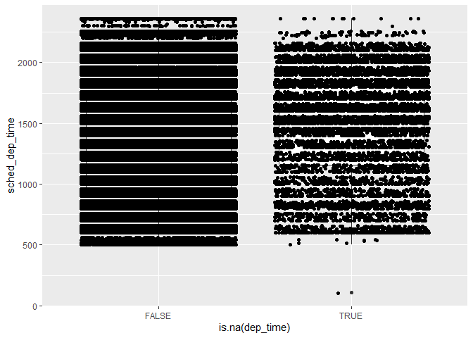

```r
#cancelled_flights <- filter(flights, is.na(flights$dep_time))
#not_cancelled_flights <- filter(flights, !is.na(flights$dep_time))

flights %>% ggplot(aes(x = is.na(dep_time), y = sched_dep_time, na.rm = FALSE)) +
  geom_boxplot(position = "dodge") +
  geom_jitter()
```

```r
  ggtitle("Scheduled departure time in non-cancelled and cancelled flights")
```

```
## $title
## [1] "Scheduled departure time in non-cancelled and cancelled flights"
##
## attr(,"class")
## [1] "labels"
```

#### 2. What variable in the diamonds dataset is most important for predicting the price of a diamond? How is that variable correlated with cut? Why does the combination of those two relationships lead to lower quality diamonds being more expensive?

```r
glimpse(diamonds)
```

```
## Observations: 53,940
## Variables: 10
## $ carat   <dbl> 0.23, 0.21, 0.23, 0.29, 0.31, 0.24, 0.24, 0.26, 0.22, 0.23,...
## $ cut     <ord> Ideal, Premium, Good, Premium, Good, Very Good, Very Good, ...
## $ color   <ord> E, E, E, I, J, J, I, H, E, H, J, J, F, J, E, E, I, J, J, J,...
## $ clarity <ord> SI2, SI1, VS1, VS2, SI2, VVS2, VVS1, SI1, VS2, VS1, SI1, VS...
## $ depth   <dbl> 61.5, 59.8, 56.9, 62.4, 63.3, 62.8, 62.3, 61.9, 65.1, 59.4,...
## $ table   <dbl> 55, 61, 65, 58, 58, 57, 57, 55, 61, 61, 55, 56, 61, 54, 62,...
## $ price   <int> 326, 326, 327, 334, 335, 336, 336, 337, 337, 338, 339, 340,...
## $ x       <dbl> 3.95, 3.89, 4.05, 4.20, 4.34, 3.94, 3.95, 4.07, 3.87, 4.00,...
## $ y       <dbl> 3.98, 3.84, 4.07, 4.23, 4.35, 3.96, 3.98, 4.11, 3.78, 4.05,...
## $ z       <dbl> 2.43, 2.31, 2.31, 2.63, 2.75, 2.48, 2.47, 2.53, 2.49, 2.39,...
```

```r
#variables to consider: carat, color, clarity, table
#which variables predict price the best?

lm(data = diamonds, price ~ carat + color + clarity + table + cut) %>% summary(.)
```

```
##
## Call:
## lm(formula = price ~ carat + color + clarity + table + cut, data = diamonds)
##
## Residuals:
##      Min       1Q   Median       3Q      Max
## -16843.5   -678.7   -198.5    464.3  10357.9
##
## Coefficients:
##              Estimate Std. Error  t value Pr(>|t|)
## (Intercept) -2640.456    157.572  -16.757  < 2e-16 ***
## carat        8893.592     12.078  736.327  < 2e-16 ***
## color.L     -1911.876     17.706 -107.979  < 2e-16 ***
## color.Q      -626.510     16.116  -38.876  < 2e-16 ***
## color.C      -170.999     15.065  -11.351  < 2e-16 ***
## color^4        20.164     13.836    1.457    0.145
## color^5       -85.778     13.071   -6.563 5.34e-11 ***
## color^6       -49.783     11.884   -4.189 2.80e-05 ***
## clarity.L    4216.374     30.819  136.812  < 2e-16 ***
## clarity.Q   -1833.656     28.816  -63.634  < 2e-16 ***
## clarity.C     923.145     24.669   37.421  < 2e-16 ***
## clarity^4    -362.910     19.731  -18.393  < 2e-16 ***
## clarity^5     216.703     16.103   13.458  < 2e-16 ***
## clarity^6       1.665     14.031    0.119    0.906
## clarity^7     110.273     12.378    8.909  < 2e-16 ***
## table         -18.541      2.719   -6.818 9.31e-12 ***
## cut.L         664.449     20.945   31.723  < 2e-16 ***
## cut.Q        -344.367     18.070  -19.058  < 2e-16 ***
## cut.C         162.714     15.769   10.319  < 2e-16 ***
## cut^4         -16.386     12.650   -1.295    0.195
## ---
## Signif. codes:  0 '***' 0.001 '**' 0.01 '*' 0.05 '.' 0.1 ' ' 1
##
## Residual standard error: 1156 on 53920 degrees of freedom
## Multiple R-squared:  0.916,  Adjusted R-squared:  0.916
## F-statistic: 3.095e+04 on 19 and 53920 DF,  p-value: < 2.2e-16
```

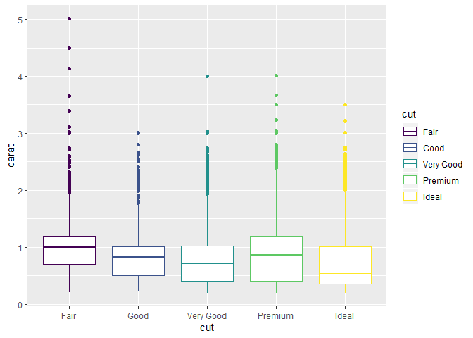

```r
#wow, that's kind of a mess, but carat seems to have the largest effect

diamonds %>% ggplot(aes(y = carat, x = cut)) +
  geom_boxplot(aes(color = cut)) +
  scale_colour_viridis_d()
```

*There seems to be an interesting relationship between cut and carat wherein high carats are associated with the worst cuts, and low-mid carats have the best average quality* *Note: I tried to use geom_point(), but that seemed to obscure things a bit, so I went back to boxplot.*

#### 3. Install the ggstance package, and create a horizontal boxplot. How does this compare to using coord_flip()?

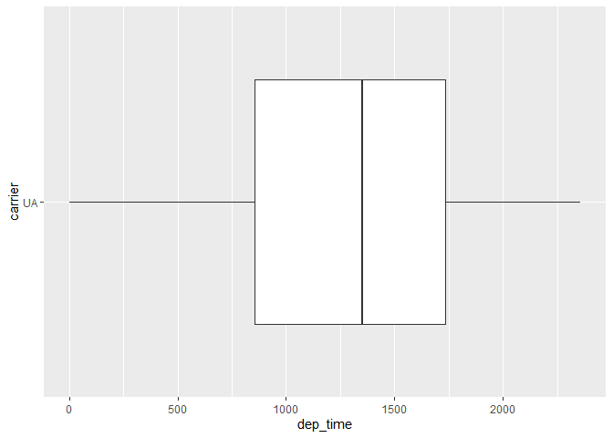

```r
#install.packages("ggstance")
#library(ggstance)
#glimpse(flights)

flights %>% filter( carrier == "UA") %>%
  ggplot(aes(x = dep_time, y = carrier)) +
  ggstance::geom_boxploth()
```

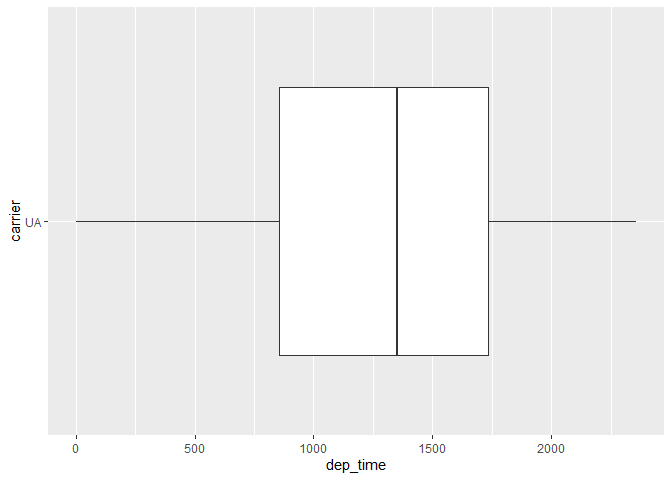

```r
flights %>% filter( carrier == "UA") %>%
  ggplot(aes(y = dep_time, x = carrier)) +
  geom_boxplot() +
  coord_flip()
```

*They look exactly the same, but I had to switch x and y variables in ggstance to get it to work.*

#### 5. Compare and contrast geom_violin() with a facetted geom_histogram(), or a coloured geom_freqpoly(). What are the pros and cons of each method?

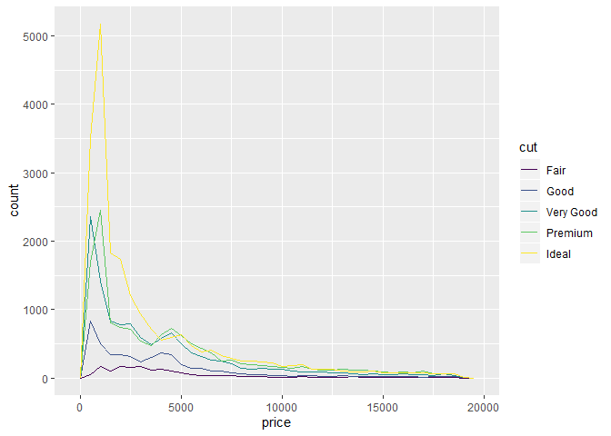

```r
ggplot(data = diamonds, mapping = aes(x = price)) +
  geom_freqpoly(mapping = aes(colour = cut), binwidth = 500)
```

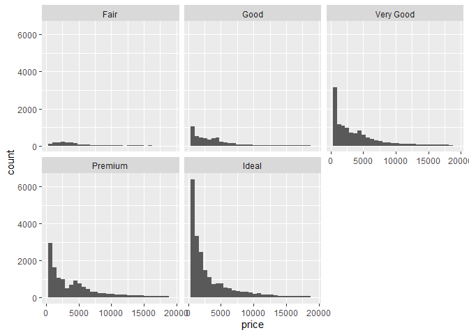

```r
ggplot(data = diamonds, mapping = aes(x = price)) +
  geom_histogram() +
  facet_wrap(vars(cut))
```

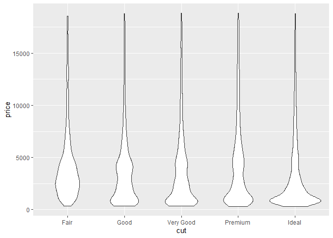

```r
ggplot(data = diamonds, mapping = aes(x = cut, y = price)) +
  geom_violin()
```

*freqpoly allows one to directly compare counts b/w different categorical variables, which is handy! However, understanding the relationships may be a bit tricky to parse. Facetting essentially takes freqpoly and separates each category into its own plot, which can be helpful for seeing intra-category distributions. Meanwhile, violin plots do away with counts entirely, and show the distributions of price for each category. One may be able to get an intuitive sense of each category’s distribution while comparing each other directly by price.*

### Last Problem

#### “Describe an *experiment* that would possess 2 *categorical* variables and 2 *continuous* variables.”

*Let us revisit the classic plant music experiment. We shall play different kinds of music over different lengths of time, and observe the effect of growth to the petiole and the stem.*  
* *categorical variables:*  
* *type of music played to plant*  
* *time*  
*continuous variables:*  
* *petiole elongation*  
* *stem elongation*